# Overwatch League Season 2022

Israel Garcia C.

2022-11-18

## Overwatch League Season 2022 Analysis

Thanks to the [official page](https://overwatchleague.com/en-us/statslab) of the league, people can search and play with the stats produced in each match. Although it provides an easy way to get insight, I found it difficult to use for specific hypothesis or topics that people might want to know. Also, it includes information of previous seasons, but they have a **different format** both in the tournaments and in the number of players, **different map** pools, between other aspects. That makes the analysis of the current season with previous information kind of useless.  
Some general considerations:  
1. The last update of the official dataset was in `10/26/2022`, but the season has already finish.  
- 1.1 This makes that the analysis incomplete, missing part of the information for the `Postseason` and all information of the `Playoffs`.  
2. This version might not be as interactive as in the official page, I plan to make it a `Shiny App` later or maybe for the following season. Another option was to make it this analysis using `SQL` and `Power BI/Tableau`, but for practice I choose to make it all in R and in Markdown.  
3. Graphics need a correct theme, I know but I am doing this in my free time as data analyst. I am trying to improve analysis and visualization. Also, I know the technical aspect of R Markdown, but I lack the ability of making pretty documents.

### Preview

|  | round_start_time | round_end_time | stage | match_id | game_number | match_winner | map_winner | map_loser | map_name | map_round | winning_team_final_map_score | losing_team_final_map_score | control_round_name | Attacker | Defender | team_home | team_away | attacker_payload_distance | defender_payload_distance | attacker_time_banked | defender_time_banked | attacker_control_perecent | defender_control_perecent | attacker_round_end_score | defender_round_end_score | total_time_match | match_rounds | stage_class | map_class | … |
| --- | --- | --- | --- | --- | --- | --- | --- | --- | --- | --- | --- | --- | --- | --- | --- | --- | --- | --- | --- | --- | --- | --- | --- | --- | --- | --- | --- | --- | --- | --- |
| 1 | 2022-05-05T19:10:00Z | 2022-05-05T19:16:00Z | 2022: Kickoff Clash: Qualifiers | 38971 | 1 | Los Angeles Gladiators | Los Angeles Gladiators | New York Excelsior | Lijiang Tower | 1 | 2 | 1 | Control Center | New York Excelsior | Los Angeles Gladiators | New York Excelsior | Los Angeles Gladiators | 0 | 0 | 0 | 0 | 100 | 99 | 1 | 0 | 5340 | 1 | Qualifiers | Control | … |
| 2 | 2022-05-05T19:16:00Z | 2022-05-05T19:21:00Z | 2022: Kickoff Clash: Qualifiers | 38971 | 1 | Los Angeles Gladiators | Los Angeles Gladiators | New York Excelsior | Lijiang Tower | 2 | 2 | 1 | Garden | New York Excelsior | Los Angeles Gladiators | New York Excelsior | Los Angeles Gladiators | 0 | 0 | 0 | 0 | 84 | 100 | 1 | 1 | 5340 | 2 | Qualifiers | Control | … |
| 3 | 2022-05-05T19:22:00Z | 2022-05-05T19:25:00Z | 2022: Kickoff Clash: Qualifiers | 38971 | 1 | Los Angeles Gladiators | Los Angeles Gladiators | New York Excelsior | Lijiang Tower | 3 | 2 | 1 | Night Market | New York Excelsior | Los Angeles Gladiators | New York Excelsior | Los Angeles Gladiators | 0 | 0 | 0 | 0 | 0 | 100 | 1 | 2 | 5340 | 3 | Qualifiers | Control | … |
| 4 | 2022-05-05T19:33:00Z | 2022-05-05T19:42:00Z | 2022: Kickoff Clash: Qualifiers | 38971 | 2 | Los Angeles Gladiators | Los Angeles Gladiators | New York Excelsior | Midtown | 1 | 2 | 0 |  | Los Angeles Gladiators | New York Excelsior | New York Excelsior | Los Angeles Gladiators | 93.84567 | 0 | 0 | 0 |  |  | 2 | 0 | 5340 | 4 | Qualifiers | Hybrid | … |
| 5 | 2022-05-05T19:43:00Z | 2022-05-05T19:47:00Z | 2022: Kickoff Clash: Qualifiers | 38971 | 2 | Los Angeles Gladiators | Los Angeles Gladiators | New York Excelsior | Midtown | 2 | 2 | 0 |  | New York Excelsior | Los Angeles Gladiators | New York Excelsior | Los Angeles Gladiators | 0 | 93.84567 | 0 | 0 |  |  | 0 | 2 | 5340 | 5 | Qualifiers | Hybrid | … |
| 6 | 2022-05-05T20:01:00Z | 2022-05-05T20:09:00Z | 2022: Kickoff Clash: Qualifiers | 38971 | 3 | Los Angeles Gladiators | New York Excelsior | Los Angeles Gladiators | Circuit royal | 1 | 3 | 3 |  | Los Angeles Gladiators | New York Excelsior | New York Excelsior | Los Angeles Gladiators | 90.67619 | 0 | 0 | 0 |  |  | 2 | 0 | 5340 | 6 | Qualifiers | Escort | … |
| 7 | 2022-05-05T20:11:00Z | 2022-05-05T20:20:00Z | 2022: Kickoff Clash: Qualifiers | 38971 | 3 | Los Angeles Gladiators | New York Excelsior | Los Angeles Gladiators | Circuit royal | 2 | 3 | 3 |  | New York Excelsior | Los Angeles Gladiators | New York Excelsior | Los Angeles Gladiators | 90.68675 | 90.67619 | 0 | 0 |  |  | 3 | 2 | 5340 | 7 | Qualifiers | Escort | … |
| 8 | 2022-05-05T20:30:00Z | 2022-05-05T20:39:00Z | 2022: Kickoff Clash: Qualifiers | 38971 | 4 | Los Angeles Gladiators | Los Angeles Gladiators | New York Excelsior | New Queen Street | 1 | 1 | 0 |  | Los Angeles Gladiators | New York Excelsior | New York Excelsior | Los Angeles Gladiators | 82.3594748 | 59.58772 | 0 | 0 |  |  | 1 | 0 | 5340 | 8 | Qualifiers | Push | … |
| 9 | 2022-05-05T21:01:00Z | 2022-05-05T21:05:00Z | 2022: Kickoff Clash: Qualifiers | 38972 | 1 | San Francisco Shock | San Francisco Shock | Paris Eternal | Ilios | 1 | 2 | 2 | Ruins | San Francisco Shock | Paris Eternal | San Francisco Shock | Paris Eternal | 0 | 0 | 0 | 0 | 100 | 37 | 1 | 0 | 3600 | 1 | Qualifiers | Control | … |
| 10 | 2022-05-05T21:06:00Z | 2022-05-05T21:11:00Z | 2022: Kickoff Clash: Qualifiers | 38972 | 1 | San Francisco Shock | San Francisco Shock | Paris Eternal | Ilios | 2 | 2 | 2 | Well | San Francisco Shock | Paris Eternal | San Francisco Shock | Paris Eternal | 0 | 0 | 0 | 0 | 100 | 69 | 2 | 0 | 3600 | 2 | Qualifiers | Control | … |

[output cut: 10 more lines]

### Match duration

The first part is to look into the match duration, in hours, for all the matches.  
As expected, *Tournaments* tend to have a larger duration than Qualifiers. This can be explained by factors such as when you lose in a tournament you are knockoff so teams try their best to don’t get eliminated as quick as possible. Also, the final match of tournaments is play in a *first to 4* format and not *first to 3*.

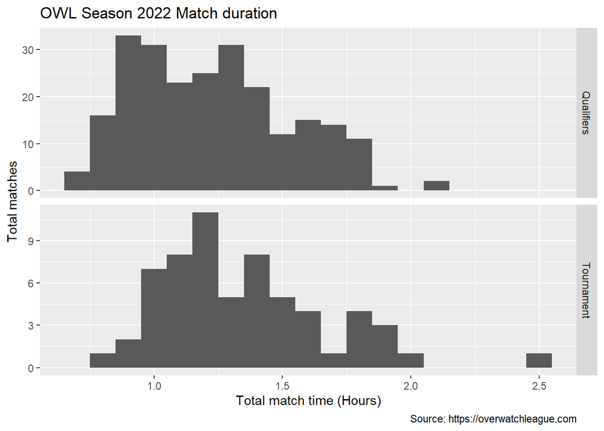

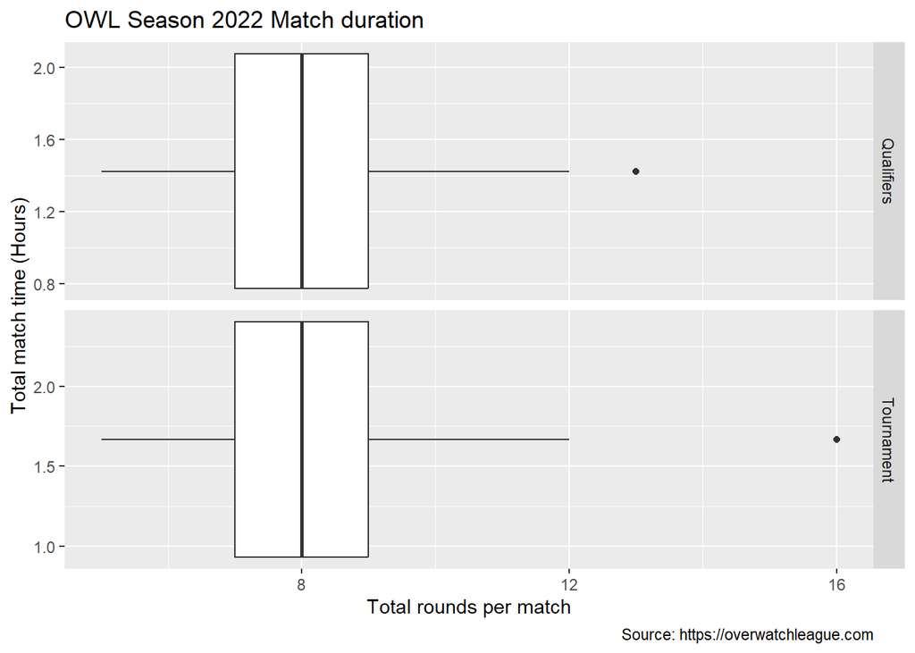

### Map pool

Overwatch counts with a variety of maps, not all of them are eligible during certain qualifiers or tournaments.  
In general, the first team to win 3 maps win the match. The order of the maps according to their type is:  
1. Control map  
2. Escort map  
3. Hybrid map, at this point it is *expected* that a team has won by a score of *3-0*. (only in Qualifiers)  
4. Push map  
5. Another control map  
On **Qualifiers**, we have the same number of Hybrid and Escort maps as they are played only once per match. Push is the fourth map to get played if there is no winner in the first three maps, and another map of Control is played as a tie breaker.  
On **Tournaments**, we have less teams and the final match is play in a *4-0* format.

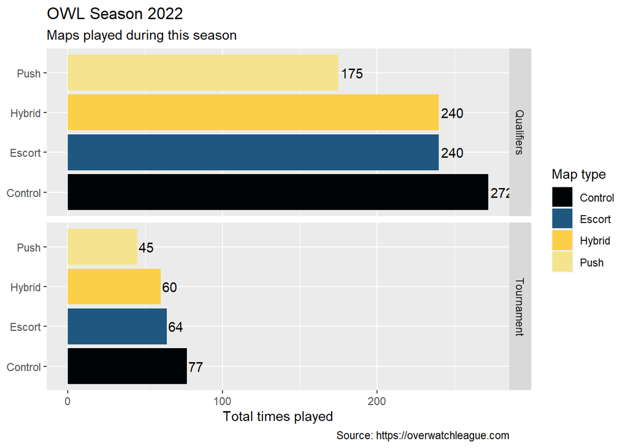

### Scores in Overwatch League

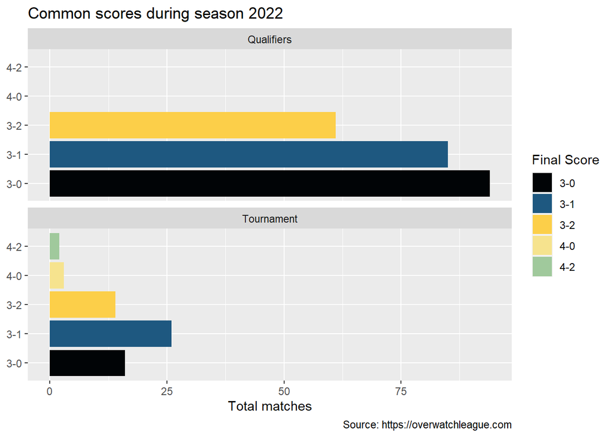

### Maps taken

As in any sports, both teams fight to get points to win. In Overwatch each point is attributed by winning a map. Obviously, the number of maps taken by losers will be less than the winners.

```
## # A tibble: 1 × 2
##   `Maps taken by winning team` `Maps taken by loser team`
##                          <dbl>                      <dbl>
## 1                          914                        267
```

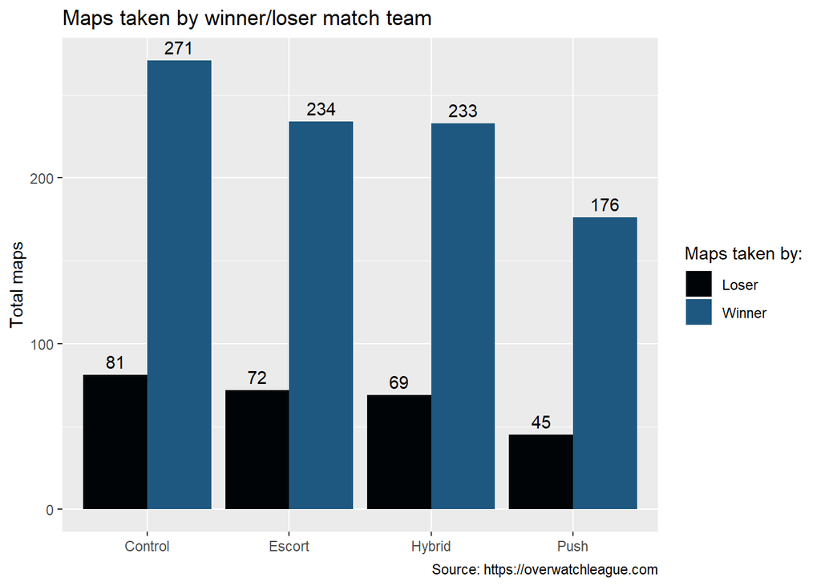

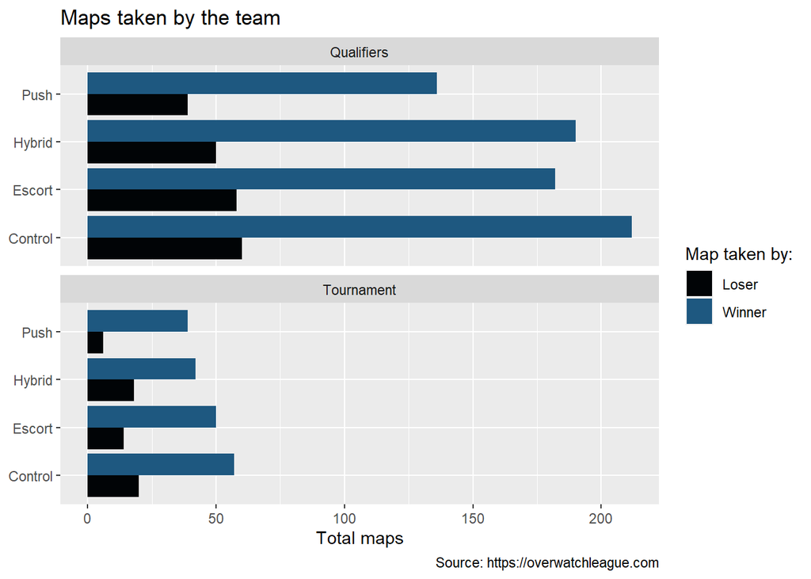

### Reverse sweep

One of the most entertaining/frustrating moments in any sports are the reverse sweeps.  
In Overwatch a reverse sweep happens when a team win all consecutive maps except for their match point map lose the following maps in a row getting a defeat.

```
## # A tibble: 2 × 2
##   reversed     n
##   <chr>    <int>
## 1 No         283
## 2 Reversed    18
```

From the numbers, it seems that a reverse sweep is quite infrequent, just `18 matches` in total for season 2022.

#### Which teams have reversed their matches?

Now, it is time to know which teams accomplish a reverse sweep in this season and against who.

[figure not shown]

#### Who got reversed sweep?

[figure not shown]

The average time to win and the number of matches can be helpful to know things like:  
- *How constant is a team at wining*.  
- The *time window* that a particular team has to win, longer times might impact certain teams.  
- The play style of teams, like *aggro, stall or control*.

```
## # A tibble: 1 × 3
##   total_time   total_wins time_to_win
##   <drtn>            <dbl>       <dbl>
## 1 1066560 secs        240        1.23
```

[figure not shown]

#### Win vs Time

Talking a little bit about of the time to get a win and the total matches won.  
> In the future I will try to do a shiny app for interactivity, I have the function for it, but no the knowledge to make the app.

[figure not shown]

### What’s next?

I haven’t finish the whole analysis, I need to develop the charts for some topics that I already have like: `global win rate`, `map winrate by team`, `First map win the match`.  
Also look into `distances, progress for the type of maps`, `individual stats` that are in other dataset, `etc`.  
Finally, continue **improving the analysis and visualisations**, and look into the **following season**.